# Resultados del Projecto Test Project

## Indicadores de salud del suelo

La siguiente tabla describe: 1. Lo que cada indicador ayuda a medir en su suelo; 2. Si desea que el valor medido sea más alto (más es mejor), más bajo (menos es mejor), o en el medio (rango óptimo); y 3. Con qué frecuencia medir cada indicador. Nuestro conocimiento de estos indicadores evoluciona rápidamente a medida que los investigadores los miden en diversos suelos, sistemas de cultivo y climas.

| Indicadores de salud del suelo | Función del suelo | Tipo de curva y mejoría |
| --- | --- | --- |
| Medir cada: 1-3 años |  |  |
| La proteína del suelo ACE | Ciclo de nutrientes, biodiversidad y hábitat, filtración y resiliencia | Más es mejor |
| La estabilidad de agregados | Soporte físico, relaciones hídricas, biodiversidad y hábitat, filtración y resiliencia | Más es mejor |
| Conductividad eléctrica (EC) | Soporte físico, ciclo de nutrientes, filtración y resiliencia | Menos es mejor |
| El carbono potencialmente mineralizable (MinC) | Ciclo de nutrientes, biodiversidad y hábitat, filtración y resiliencia | Más es mejor |
| El carbono oxidable de permanganato (POXC) | Biodiversidad y hábitat, Ciclo de nutrientes, filtración y resiliencia | Más es mejor |
| El nitrógeno potencialmente mineralizable (PMN) | Ciclo de nutrientes, biodiversidad y hábitat, filtración y resiliencia | Más es mejor |
| El pH del suelo | Nutrient cycling, filtración y resiliencia | Rango óptimo |
| Nitrógeno total | Ciclo de nutrientes, biodiversidad y hábitat, filtración y resiliencia | Rango óptimo |
| Los nutrientes esenciales de las plantas | Ciclo de nutrientes | Rango óptimo |
| Medir cada: 3-5 años |  |  |
| Densidad aparente | Soporte físico, relaciones hídricas, biodiversidad y hábitat, filtración y resiliencia | Rango óptimo |
| Capacidad de intercambio catiónico (CEC) | Ciclo de nutrientes, filtración y resiliencia | Más es mejor |
| La infiltración | Relaciones hídricas, soporte físico | Más es mejor |
| Materia organica (SOM) | Ciclo de nutrientes, filtración y resiliencia | Más es mejor |
| Capacidad de retención de agua (WHC) | Relaciones hídricas, soporte físico | Más es mejor |

## Pruebas de salud del suelo

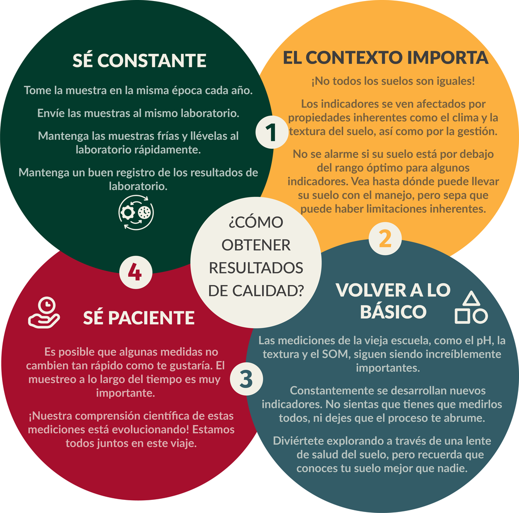

## Comprender los resultados de la salud del suelo

Para obtener más información sobre cómo interpretar los resultados de la salud del suelo, vea el seminario web de Dani Gelardi [“Comprender las pruebas de suelo”](https://youtu.be/-ED-gGk4yb8?si=fxfnxqrRqhkGDaiu).